# UOC. PAC2 Visualització de Dades

Laura Ling García González

2025-04-03

L’objectiu d’aquesta pràctica és explorar tres tipus de visualitzacions de dades: l’histograma, un **isotype chart** i un **beeswarm chart**.

Per tal de posar en pràctica cada una de les visualitzacions utilitzarem l’eina RStudio per tal de realitzar cadascuna de les representacions.

El conjunt de dades escollit per aquest anàlisi s’ha obtingut de [Kaggle](https://www.kaggle.com/datasets/spscientist/students-performance-in-exams), anomenat **Students Performance in Exams** que compta amb 1000 dades i les següents 8 variables:

1. **gender**: gènere de cada alumne (female,male);
2. **race.ethnicity**: ètnia de cada alumne amb classificació segons grup (A, B, C, D, E);
3. **parental.level.of.education**: nivell d’educació dels pares (bachelor’s degree, some college, master’s degree, associate’s degree, high school, some high school);
4. **lunch**: classificats segons standard o free/reduced;
5. **test.preparation.course**: si els alumnes han realitzat alguna preparació prèvia als examens (none, completed);
6. **math.score**: nota de cada alumne a l’examen de matemàtiques;
7. **reading.score**: nota de cada alumne a l’examen de lectura;
8. **writing.score**: nota de cada alumne a l’examen de redacció.

És una base de dades que conté les classificacions obtingudes pels estudiants en diverses assignatures per tal de comprendre la influencia dels antecedents familiars, la preparació dels examens o el rendiment dels estudiants entre altres.

Per carregar les dades (es tracta d’un arxiu .csv) a RStudio ho podem fer de la següent manera:

```r
library(dplyr)
StudentsPerformance <- read.csv("C:/Users/usuario/Desktop/Master/UOC/Visualització de dades/BLOC2/StudentsPerformance.csv", sep=",", header=TRUE, stringsAsFactors=FALSE)

#Per a la visualització general del dataset
glimpse(StudentsPerformance)
```

```
## Rows: 1,000
## Columns: 8
## $ gender                      <chr> "female", "female", "female", "male", "mal…
## $ race.ethnicity              <chr> "group B", "group C", "group B", "group A"…
## $ parental.level.of.education <chr> "bachelor's degree", "some college", "mast…
## $ lunch                       <chr> "standard", "standard", "standard", "free/…
## $ test.preparation.course     <chr> "none", "completed", "none", "none", "none…
## $ math.score                  <int> 72, 69, 90, 47, 76, 71, 88, 40, 64, 38, 58…
## $ reading.score               <int> 72, 90, 95, 57, 78, 83, 95, 43, 64, 60, 54…
## $ writing.score               <int> 74, 88, 93, 44, 75, 78, 92, 39, 67, 50, 52…
```

## Histograma

El [histograma](https://www.data-to-viz.com/#histogram) és una tècnica de visualització que permet analitzar la distribució de dades numèriques contínues. Va ser popularitzat per l’estadístic [Karl Pearson](https://datavizproject.com/data-type/histogram/) a finals del segle XIX, tot i que el concepte de representar freqüències amb barres ja existia anteriorment. Funciona agrupant les dades en intervals (anomenats [bins](https://datavizcatalogue.com/ES/metodos/histograma.html)) i mostrant la freqüència de cada interval amb barres verticals, on l’alçada reflecteix el nombre de casos dins de cada rang. És ideal per identificar patrons com la simetria, la dispersió o la presència de valors atípics en variables com edats, temperatures o ingressos.

Les dades adequades són quantitatives i contínues (per exemple, mesures o valors que poden prendre decimals), i es recomana un mínim de 30 observacions per evitar interpretacions enganyoses.

Una limitació important és que l’elecció de l’amplada dels intervals pot alterar la percepció de la distribució: intervals massa estrets generen soroll, mentre que els massa amples amaguen detalls.

Per a les nostres dades, podem crear un histograma amb [ggplot](https://r-graph-gallery.com/histogram) segons les notes dels alumnes a l’examen de matemàtiques, per tal de veure la tendència general respecte la nota mitjana de tots ells, ja que ens agrupa les notes en intervals i mostra quantes persones cauen en cada rang, permetent-nos identificar on es concentren la majoria de les notes, la simetria o presència de possibles grups diferenciats. Afagirem també la mitjana de les notes totals, representada en vermell.

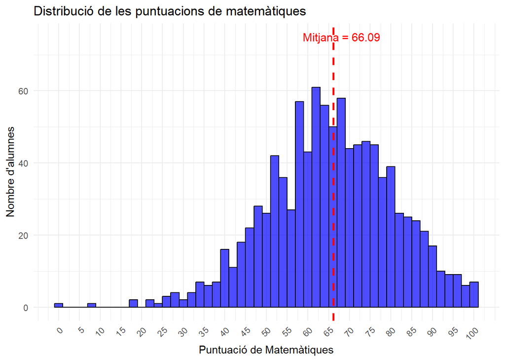

```r
# Carregar les llibreries necessàries
library(ggplot2)

# A continuació, es crea el histograma utilitzant ggplot2

# Calcular la mitjana de les puntuacions de matemàtiques
mitjana_math <- mean(StudentsPerformance$math.score)

# Crear histograma de math.score amb bins més petits i una línia vertical per la mitjana
ggplot(StudentsPerformance, aes(x = math.score)) +
  geom_histogram(binwidth = 2, fill = "blue", color = "black", alpha = 0.7) +  # Ajustem el binwidth
  labs(
    title = "Distribució de les puntuacions de matemàtiques",
    x = "Puntuació de Matemàtiques",
    y = "Nombre d'alumnes"
  ) +
  scale_x_continuous(breaks = seq(0, 100, by = 5)) +  # Afegim etiquetes més detallades a l'eix X
  theme_minimal() +
  theme(axis.text.x = element_text(angle = 45, hjust = 1)) +  # Inclinem les etiquetes de l'eix X per millorar la llegibilitat
  geom_vline(aes(xintercept = mitjana_math), color = "red", linetype = "dashed", size = 1) +  # Afegim la línia vertical per la mitjana
  annotate("text", x = mitjana_math + 2, y = 75, label = paste("Mitjana =", round(mitjana_math, 2)), color = "red", size = 4)  # Afegim el text de la mitjana
```

Podem veure que la majoria dels alumnes superen la puntuació de 50, tenint una mitjana poblacional de una puntuació de 66.09. Podem fer el mateix estudi amb la resta de les puntuacions.

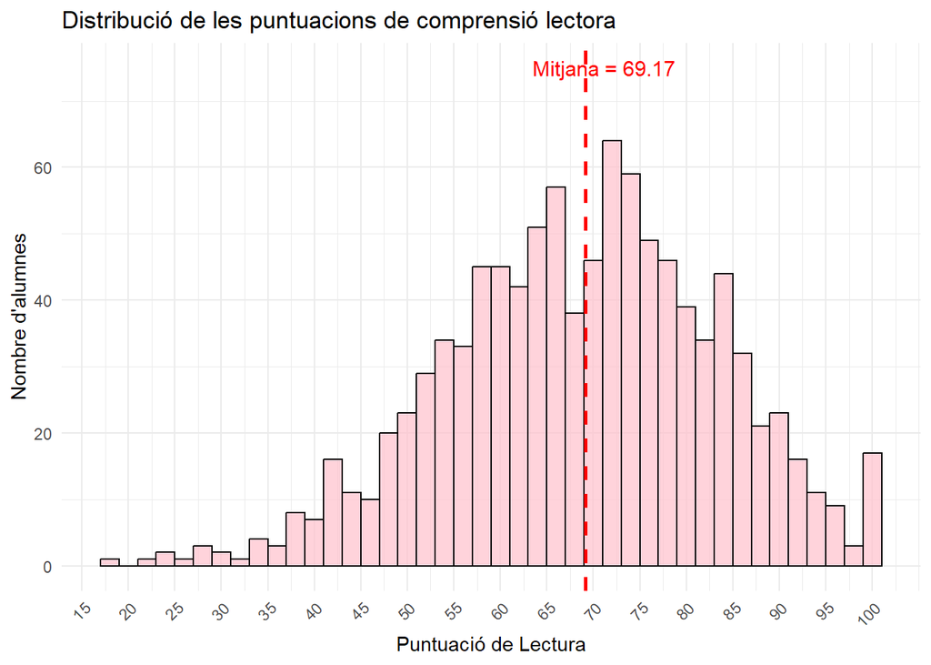

```r
# Calcular la mitjana de les puntuacions de lectura
mitjana_reading <- mean(StudentsPerformance$reading.score)

# Crear histograma de math.score amb bins més petits i una línia vertical per la mitjana
ggplot(StudentsPerformance, aes(x = reading.score)) +
  geom_histogram(binwidth = 2, fill = "pink", color = "black", alpha = 0.7) +  # Ajustem el binwidth
  labs(
    title = "Distribució de les puntuacions de comprensió lectora",
    x = "Puntuació de Lectura",
    y = "Nombre d'alumnes"
  ) +
  scale_x_continuous(breaks = seq(0, 100, by = 5)) +  # Afegim etiquetes més detallades a l'eix X
  theme_minimal() +
  theme(axis.text.x = element_text(angle = 45, hjust = 1)) +  # Inclinem les etiquetes de l'eix X per millorar la llegibilitat
  geom_vline(aes(xintercept = mitjana_reading), color = "red", linetype = "dashed", size = 1) +  # Afegim la línia vertical per la mitjana
  annotate("text", x = mitjana_reading + 2, y = 75, label = paste("Mitjana =", round(mitjana_reading, 2)), color = "red", size = 4)  # Afegim el text de la mitjana
```

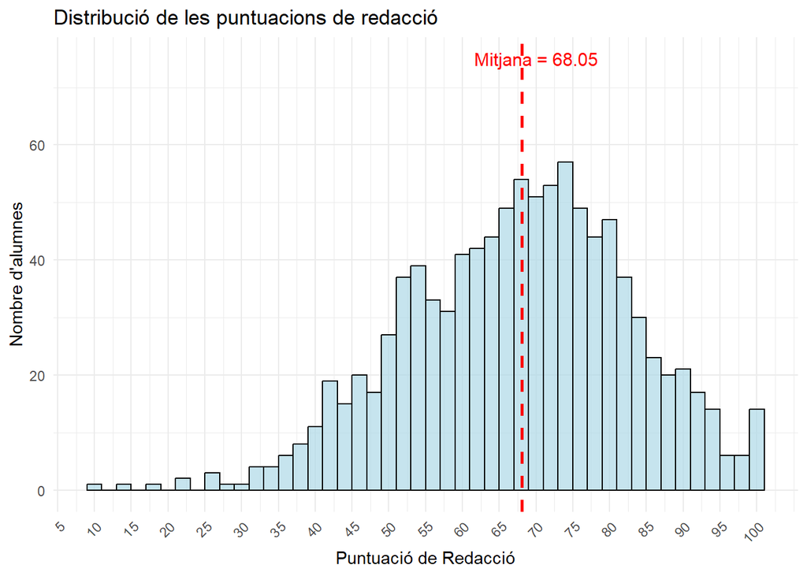

```r
# Calcular la mitjana de les puntuacions de lectura
mitjana_writing <- mean(StudentsPerformance$writing.score)

# Crear histograma de math.score amb bins més petits i una línia vertical per la mitjana
ggplot(StudentsPerformance, aes(x = writing.score)) +
  geom_histogram(binwidth = 2, fill = "lightblue", color = "black", alpha = 0.7) +  # Ajustem el binwidth
  labs(
    title = "Distribució de les puntuacions de redacció",
    x = "Puntuació de Redacció",
    y = "Nombre d'alumnes"
  ) +
  scale_x_continuous(breaks = seq(0, 100, by = 5)) +  # Afegim etiquetes més detallades a l'eix X
  theme_minimal() +
  theme(axis.text.x = element_text(angle = 45, hjust = 1)) +  # Inclinem les etiquetes de l'eix X per millorar la llegibilitat
  geom_vline(aes(xintercept = mitjana_writing), color = "red", linetype = "dashed", size = 1) +  # Afegim la línia vertical per la mitjana
  annotate("text", x = mitjana_writing + 2, y = 75, label = paste("Mitjana =", round(mitjana_writing, 2)), color = "red", size = 4)  # Afegim el text de la mitjana
```

Podem veure que en la redacció com en la comprensió lectora s’obtenen aproximadament els mateixos resultats, obtenint mitjanes de puntuacions de 68.05 i 69.17 respectivament, cosa que son lleugerament superiors a la mitjana en matemàtiques.

## Beeswarm Chart

El [beeswarm chart](https://datavizproject.com/data-type/beeswarm-blot/) (o diagrama d’eixam) és una tècnica que visualitza dades individuals sense superposar-los, creant un efecte similar a un eixam d’abelles. Deriva de gràfics de punts tradicionals (com el scatter plot), però optimitza l’espai mitjançant algorismes que distribueixen els punts de manera uniforme al llarg d’un eix. Va guanyar rellevància en àmbits com la biologia o les ciències socials per analitzar distribucions en mostres mitjanes (entre 100 i 500 mostres).

És ideal per a dades quantitatives agrupades en categories (com comparar l’alçada de persones per país o notes d’exàmens per assignatura), ja que mostra tant la densitat com els valors individuals.

Les seves principals limitacions són la dificultat per gestionar conjunts massius (>1000 mostres) i la necessitat d’eines específiques per generar l’efecte d’eixam. A diferència de l’histograma, preserva la precisió de cada dada, cosa que el fa útil per a anàlisis detallades però requereix més atenció per part de l’usuari.

En el nostre cas podem fer un gràfic amb el paquet [ggbeeswarm](https://r-charts.com/distribution/ggbeeswarm/) que té R, per classificar la les notes de cada alumne segons el grup ètnic dels alumnes i el seu gènere.

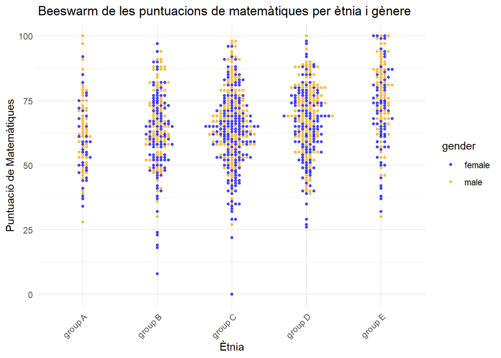

```r
# Instal·lar i carregar el paquet ggbeeswarm (si no el tens instal·lat)
#install.packages("ggbeeswarm")
library(ggbeeswarm)

# Crear beeswarm chart separant per ètnia i amb el gènere com a color
ggplot(StudentsPerformance, aes(x = race.ethnicity, y = math.score, color = gender)) +
  geom_beeswarm(size = 1, alpha = 0.7) +  # Afegim el beeswarm amb mida i transparència
  labs(
    title = "Beeswarm de les puntuacions de matemàtiques per ètnia i gènere",
    x = "Ètnia",
    y = "Puntuació de Matemàtiques"
  ) +
  scale_color_manual(values = c("female" = "blue", "male" = "orange")) +  # Assignem colors als gèneres
  theme_minimal() +
  theme(axis.text.x = element_text(angle = 45, hjust = 1))  # Inclinem les etiquetes de l'eix X per millorar la llegibilitat
```

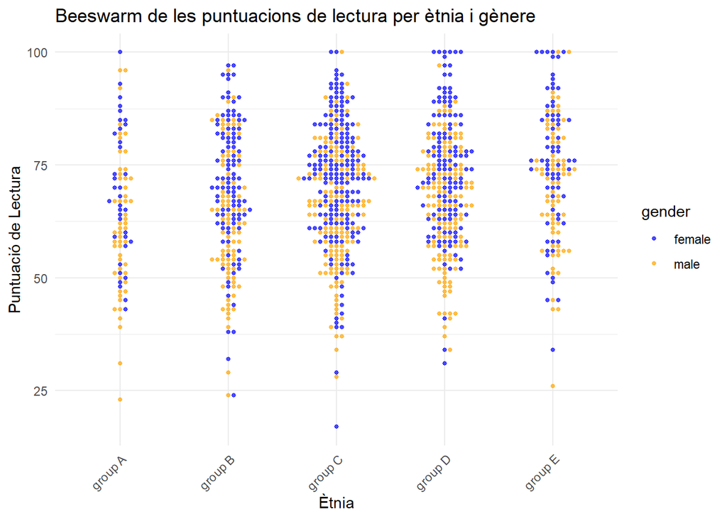

```r
# Crear beeswarm chart separant per ètnia i amb el gènere com a color
ggplot(StudentsPerformance, aes(x = race.ethnicity, y = reading.score, color = gender)) +
  geom_beeswarm(size = 1, alpha = 0.7) +  # Afegim el beeswarm amb mida i transparència
  labs(
    title = "Beeswarm de les puntuacions de lectura per ètnia i gènere",
    x = "Ètnia",
    y = "Puntuació de Lectura"
  ) +
  scale_color_manual(values = c("female" = "blue", "male" = "orange")) +  # Assignem colors als gèneres
  theme_minimal() +
  theme(axis.text.x = element_text(angle = 45, hjust = 1))  # Inclinem les etiquetes de l'eix X per millorar la llegibilitat
```

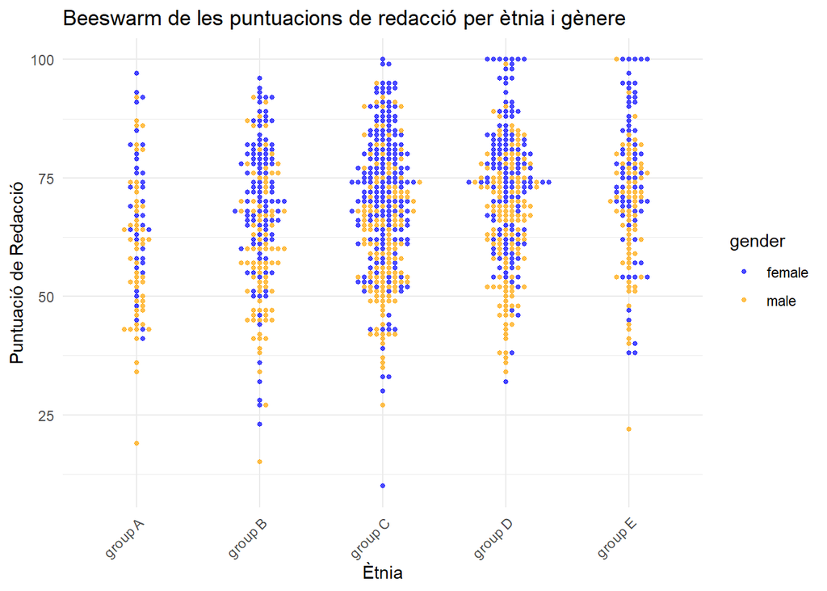

```r
# Crear beeswarm chart separant per ètnia i amb el gènere com a color
ggplot(StudentsPerformance, aes(x = race.ethnicity, y = writing.score, color = gender)) +
  geom_beeswarm(size = 1, alpha = 0.7) +  # Afegim el beeswarm amb mida i transparència
  labs(
    title = "Beeswarm de les puntuacions de redacció per ètnia i gènere",
    x = "Ètnia",
    y = "Puntuació de Redacció"
  ) +
  scale_color_manual(values = c("female" = "blue", "male" = "orange")) +  # Assignem colors als gèneres
  theme_minimal() +
  theme(axis.text.x = element_text(angle = 45, hjust = 1))  # Inclinem les etiquetes de l'eix X per millorar la llegibilitat
```

En primer lloc observem que el grup C és el més poblat de les 5 ètnies i podem observar que en general tots els grups semblen a col·locar-se en posicions similars segons les notes, de manera que no hi ha cap que impliqui que hi hagi menys capacitats de rendiment en els exàmens que els altres.

Sí que podem observar que en matemàtiques, tot i que les notes son bastant equitatives segons el gènere, sembla que els homes tenen tendència a obtenir millors resultats en aquesta matèria, sense distinció de ètnia, ja que els colors taronjes semblen estar situats en posicions lleugerament més altes que els punts blaus que representen les dones.

En canvi, en la prova de lectura i la d’escriptura podem veure qu és al contrari, les dones semblen obtenir millors resultats que els homes.

## Isotype chart

El gràfic Isotype és una tècnica dissenyada per comunicar dades de manera visualment intuïtiva mitjançant [icones o símbols](https://datavizproject.com/data-type/fraction-of-pictograms/). Va ser creat pel filòsof Otto Neurath als anys 1920 com a part del moviment Isotype (International System of Typographic Picture Education), amb l’objectiu de democratitzar l’accés a la informació. Cada icona representa una quantitat concreta (per exemple, una casa = 1000 habitatges), permetent comparacions ràpides entre categories.

És útil per a dades qualitatives o quantitatives discretes (com el nombre d’escoles per regió o espècies animals en un ecosistema), sempre que es puguin associar a símbols reconeixibles

Les dades han de ser senceres i eviten decimals per garantir claredat. Tot i la seva accessibilitat, aquesta tècnica no és adequada per a valors molt grans o variables complexes, ja que l’excessiva repetició d’icones pot dificultar la lectura.

Amb el nostre dataset podem fer una classificació segons les notes i el tipus de dinar que han consumit els alumnes. Per exemple, podem caregoritzar segons la mitjana de les notes de cada alumne entre alta (qualificacions de 80 a 100), mitjana (60 a 80) i baixa (menors a 60). Podem veure quants alumnes de cada categoria han sonsumit un tipus de dinar o altre i veure si el tipus d’alimentació influeix en el rendiment total en els examens. Per a un dinar estàndard ho representarem amb pomes vermelles i el menjar gratuït/reduït serà representat amb pomes grises. El gràfic final obté per cada franja 10 pomes, que representen la quanttat d’alumnes que han ingerit un tipus de menjar o altre segons el rendiment. Per les icones utilitzarem la llibreria [emojifont](https://cran.r-project.org/web/packages/emojifont/vignettes/emojifont.html).

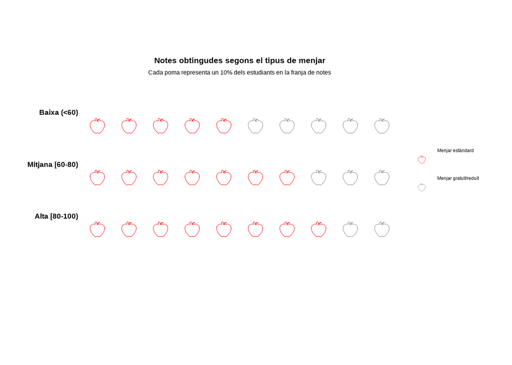

```r
library(tidyr)
library(emojifont)

load.emojifont()

#Configurar dades i ordenar franges
StudentsPerformance <- StudentsPerformance %>%
  mutate(
    average_score = (math.score + reading.score + writing.score) / 3,
    performance = case_when(
      average_score >= 80 ~ "Alta [80-100)",
      average_score >= 60 & average_score < 80 ~ "Mitjana [60-80)",  # Afegir el límit superior a 80
      TRUE ~ "Baixa (<60)"
    ) %>% factor(levels = c("Alta [80-100)", "Mitjana [60-80)", "Baixa (<60)"))
  )

#Preparar dades amb posicions ordenades
df_plot <- StudentsPerformance %>%
  group_by(performance) %>%
  summarise(
    standard_prop = sum(lunch == "standard") / n(),
    free_prop = 1 - standard_prop
  ) %>%
  mutate(
    standard_pomes = round(standard_prop * 10),
    free_pomes = 10 - standard_pomes
  ) %>%
  pivot_longer(
    cols = c(standard_pomes, free_pomes),
    names_to = "tipus",
    values_to = "n_pomes"
  ) %>%
  mutate(
    color = ifelse(tipus == "standard_pomes", "#FF0000", "#808080"),
    emoji = "🍎"
  ) %>%
  uncount(n_pomes) %>%
  group_by(performance) %>%
  mutate(posicio = row_number())

# Crear el gràfic
ggplot(df_plot, aes(x = posicio, y = performance, color = color)) +
  geom_text(
    aes(label = emoji),
    family = "EmojiOne",
    size = 12,
    position = position_nudge(x=-0.2, y = 0.1)
  ) +
  scale_color_manual(
    values = c("#FF0000" = "#FF0000", "#808080" = "#808080"),
    breaks = c("#FF0000", "#808080"),
    labels = c(" Menjar estàndard", " Menjar gratuït/reduït"),
    guide = guide_legend(
      title = NULL,
      override.aes = list(
        label = "🍎",     # Afegeix l'emoji
        size = 6          # Ajusta la mida de la poma a la llegenda
      )
    )
  ) +
  labs(
    title = "Notes obtingudes segons el tipus de menjar",
    subtitle = "Cada poma representa un 10% dels estudiants en la franja de notes",
    x = NULL,
    y = NULL
  ) +
  theme_minimal() +
  theme(
    axis.text.x = element_blank(),
    axis.text.y = element_text(size = 14, face = "bold", color = "black"),  # Mostra franges
    panel.grid = element_blank(),
    plot.title = element_text(hjust = 0.5, face = "bold", size = 16),       # Títol centrat i negreta
    plot.subtitle = element_text(hjust = 0.5, size = 12),
    plot.margin = margin(2, 1, 4, 1, "cm")  # Espai per la llegenda
  )
```

En el gràfic podem veure que 5 de cada 10 persones que han obtingut baixa qualificació han menjat menjar estàndard. En les qualificacions mitjanes, ha estat 7 de cada 10 alumnes i, finalment, 8 de cada 10 estudiants que han obtingut qualificacions altes han consumit menjar estàndard. Amb això podem concloure que que el més probable és que les famílies que no té problemes econòmics, per tant, que es poden permetre un dinar estàndard acostumen a treure millors notes, que la gent que té menys recursos. Per tant podem dir que la riquesa econòmica d’una persona influeix bastant en el rendiment dels estudiants.